# Modeling with DAG

**The 8th assignment is meant to give you some practive with translating problems into the linear model framework.**

# Significance in prediction vs inference

If the data is generating in the following manner…

```r
n<-1000
X<-rnorm(n,-5,1)
Y<-rnorm(n,5,1)
Z<-matrix(X+Y+rnorm(n,0,1),ncol=1)
```

And we have no idea about it. The possible wrong solution for studying Y would be fit Y on X and Z, and can be visualized as…

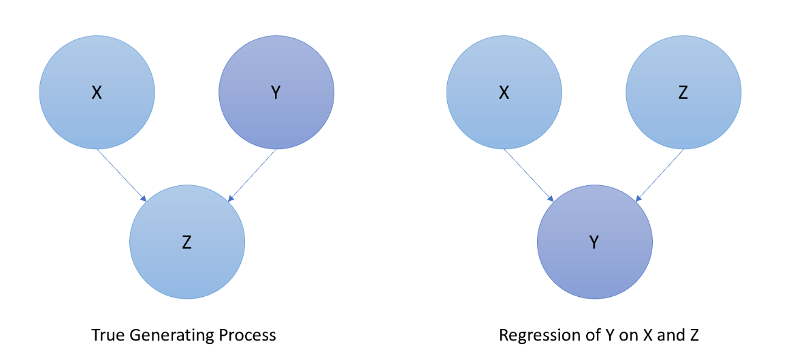

```r
modelz<-lm(Y~Z)
modelxz<-lm(Y~Z+X)
n<-100
X_new<-rnorm(n,-5,1)
Y_new<-rnorm(n,5,1)
Z_new<-data.frame(X_new+Y_new+rnorm(n,0,1))
predz<-modelz$coefficients[1]+modelz$coefficients[2]*Z_new
predxz<-modelxz$coefficients[1]+modelxz$coefficients[2]*Z_new+modelxz$coefficients[3]*X_new
sum((predz-Y_new)^2)/100
```

```
[1] 0.6818074
```

```r
sum((predxz-Y_new)^2)/100
```

```
[1] 0.5072413
```

The losts of the two models are printed. Then we trying to figure out if there are any difference between the two:

```r
set.seed(NULL)
s<-100
error<-matrix(NA,ncol=2,nrow=s)
for(i in 1:s){
  X_new<-rnorm(n,-5,1)
  Y_new<-rnorm(n,5,1)
  Z_new<-data.frame(X_new+Y_new+rnorm(n,0,1))
  predz<-modelz$coefficients[1]+modelz$coefficients[2]*Z_new
  predxz<-modelxz$coefficients[1]+modelxz$coefficients[2]*Z_new+modelxz$coefficients[3]*X_new
  error[i,1]<-sum((predz-Y_new)^2)/100
  error[i,2]<-sum((predxz-Y_new)^2)/100
}
diff<-error[,1]-error[,2]
quantile(diff,c(0.025,0.975))
```

```
      2.5%      97.5%
0.05477115 0.31815643
```

As zero does not fall into the interval, we can say that there exists significance difference between the two models.

```r
index<-rep(1:10,100)
error2<-matrix(NA,ncol=2,nrow=10)
data<-matrix(cbind(X,Y,Z,index),ncol=4)
for(i in 1:10){
  test<-data.frame(matrix(data[index==i],ncol=4))
  colnames(test)<-c("X","Y","Z","index")
  train<-data.frame(matrix(data[index!=i],ncol=4))
  colnames(train)<-c("X","Y","Z","index")

  m1<-lm(Y~Z,data=train)
  pred1<-m1$coefficients[1]+m1$coefficients[2]*test$Z
  error2[i,1]<-sum((pred1-test$Y)^2)
  m2<-lm(Y~Z+X,data=train)
  pred2<-m2$coefficients[1]+m2$coefficients[2]*test$Z+m2$coefficients[3]*test$X
  error2[i,2]<-sum((pred2-test$Y)^2)
}
diff<-abs(error2[,2]-error2[,1])
t<-mean(diff)/(sqrt((9*var(error2[,1])+9*var(error2[,2]))/18)*sqrt(1/5))
t<-mean(diff)*sqrt(10)/sd(diff)
#t-test
t.test(error2[,2],error2[,1],var.equal = FALSE,conf.level = 0.95)
```

```
    Welch Two Sample t-test

data:  error2[, 2] and error2[, 1]
t = -4.9324, df = 11.564, p-value = 0.0003865
alternative hypothesis: true difference in means is not equal to 0
95 percent confidence interval:
 -26.97746 -10.39804
sample estimates:
mean of x mean of y
 45.76059  64.44834
```

The conclusion of the difference was again confirmed with the t-test since the p-value of the t-test is below 0.05 based on which we reject the null hypothesis. The parameter between X and Y has no meaning because no causality exists between the two. The parameter between Z and Y do explain some correlation between the two variables. However, the significance test for the coefficient is meaningless since all other assumptions are violated.

# DAG

### Example studying obesity and checkups

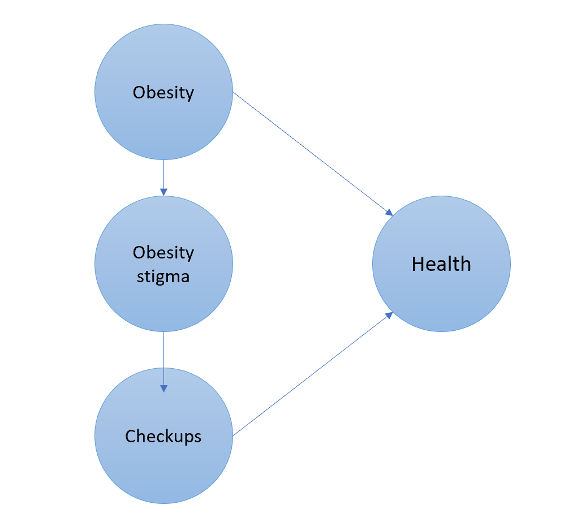

An inference would be https://www.ncbi.nlm.nih.gov/pmc/articles/PMC4381543/.

# Wrong model’s validation

```r
n<-100
X<-rnorm(100,0,0.9)
Y<-1+5*sin(X)+rnorm(n,0,1)
model1<-lm(Y~X)
sigma2<-crossprod(Y-model1$fitted.values)/(n-2)
#generate new X and Y
X_new<-seq(min(X),max(X),length.out = 10)
Y_hat<-model1$coefficients[1]+model1$coefficients[2]*X_new
Y_new<-matrix(NA,ncol=10,nrow=n)
for(i in 1:10){
  Y_new[,i]<-rnorm(n,Y_hat[i],sqrt(sigma2))
}
CI<-apply(Y_new,2,quantile,c(0.05,0.95))
plot(X,Y)
lines(X_new,CI[1,],col="blue")
```

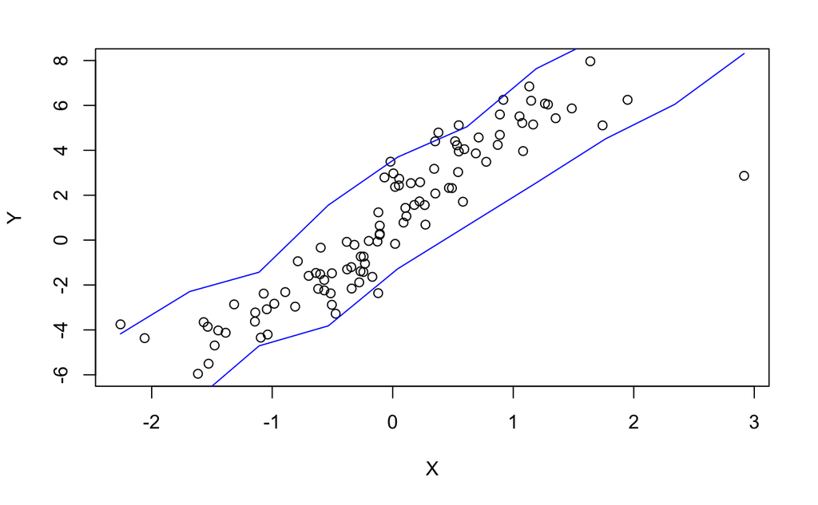

```r
lines(X_new,CI[2,],col="blue")
```

The true data was generated with sin(X) but fitted with X. We create a 90% prediction interval at 10 equally spaced values of X_new ranging from the smallest to the largest value in the original data X (shown in the blue lines).

The wrong model cound do reasonably at certain regions of the data. However, if we look closer at the plot, we can spot a tendency that the predicted area is off the trend of the data. The true data generating process is never known in the real world. By this simulation, we have a taste of how the model is deficient.